# An evening with an R Lady from HaRvard: How to build your first neural network

Kristen Hunter  
17 July 2017

Part I: Introduction to Neural Networks

### What is a neural network?

- Predictive machine learning algorithm
- Takes in inputs and outputs a prediction
  - Classification: Predicts a category (political party, character, color)
  - Regression: Predicts a number (temperature, stock price, cell count)

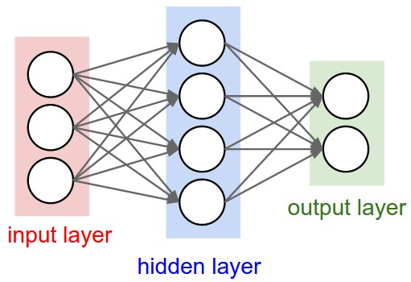

[figure not shown]

### Data Example: Predicting Wine Type

```r
wine = read.csv('https://archive.ics.uci.edu/ml/machine-learning-databases/wine/wine.data')
names(wine) = c('label', 'alcohol', 'malic_acid', 'ash', 'alcalinity_of_ash',
                  'magnesium', 'total_phenols', 'flavanoids', 'nonflavanoid_phenols',
                  'proanthocyanins', 'color_intensity', 'hue', 'OD280_OD315_of_diluted_wines',
                  'proline')
wine$id = as.character(seq(1, nrow(wine)))
head(wine)
```

```
  label alcohol malic_acid  ash alcalinity_of_ash magnesium total_phenols
1     1   13.20       1.78 2.14              11.2       100          2.65
2     1   13.16       2.36 2.67              18.6       101          2.80
3     1   14.37       1.95 2.50              16.8       113          3.85
4     1   13.24       2.59 2.87              21.0       118          2.80
5     1   14.20       1.76 2.45              15.2       112          3.27
6     1   14.39       1.87 2.45              14.6        96          2.50
  flavanoids nonflavanoid_phenols proanthocyanins color_intensity  hue
1       2.76                 0.26            1.28            4.38 1.05
2       3.24                 0.30            2.81            5.68 1.03
3       3.49                 0.24            2.18            7.80 0.86
4       2.69                 0.39            1.82            4.32 1.04
5       3.39                 0.34            1.97            6.75 1.05
6       2.52                 0.30            1.98            5.25 1.02
  OD280_OD315_of_diluted_wines proline id
1                         3.40    1050  1
2                         3.17    1185  2
3                         3.45    1480  3
4                         2.93     735  4
5                         2.85    1450  5
6                         3.58    1290  6
```

### Neurons in the Brain

- Neurons in the brain fire when a stimulus causes their electrical current to exceed a certain threshold

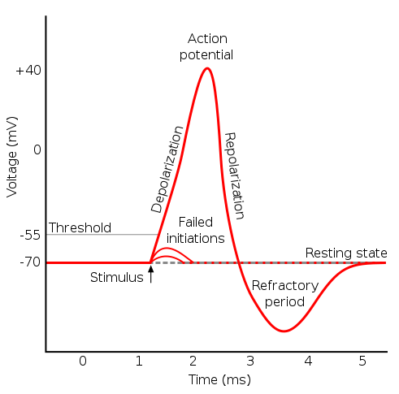

[figure not shown]

### Modeling Neurons

- We can model the firing of a neuron using a step function
- Activation function: is this neuron active, i.e. will it pass along its signal?

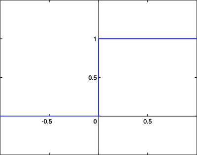

### Perceptron

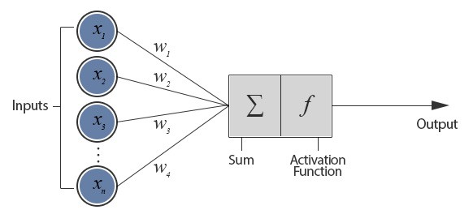

- Node in a neural network (like neuron in the brain)
- Takes in inputs (\( x_1 \), \( x_2 \)) and weights (\( w_1 \), \( w_2 \)) as a weighted sum
- Processes inputs and weights using activation function: \[ f(w_1 \cdot x_1 + w_2 \cdot x_2) \]
- If activation functions reaches particular threshold, it fires

### Modeling Neurons

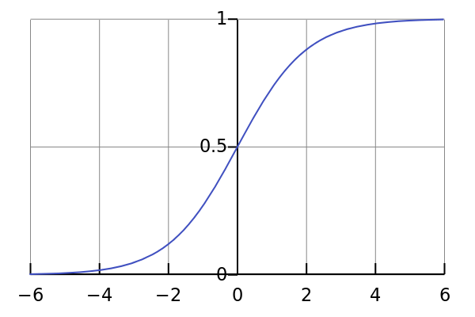

- Sometimes we prefer a 'fuzzier' signal for our activation function
- Rather than a yes/no for whether a perceptron has fired, we give a value between 0 and 1
- Determines the strength of the signal
- Examples: logistic function, other sigmoid functions

[figure not shown]

### Neural Network Structure

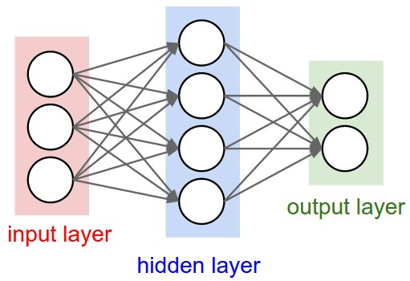

- Input layer: Features (also known as covariates or independent variables)
- Hidden layer: Perceptrons
- Output layer: Prediction

### Supervised machine learning

- You 'train' the algorithm with a set of inputs with known outputs, or labels
  - neural networks, linear regression, support vector machines, random forests

### Supervised Machine Learning

[figure not shown]

### Unsupervised machine learning

- The algorithm does not get known outputs/labels
  - clustering, principal components analysis

### Unsupervised Machine Learning

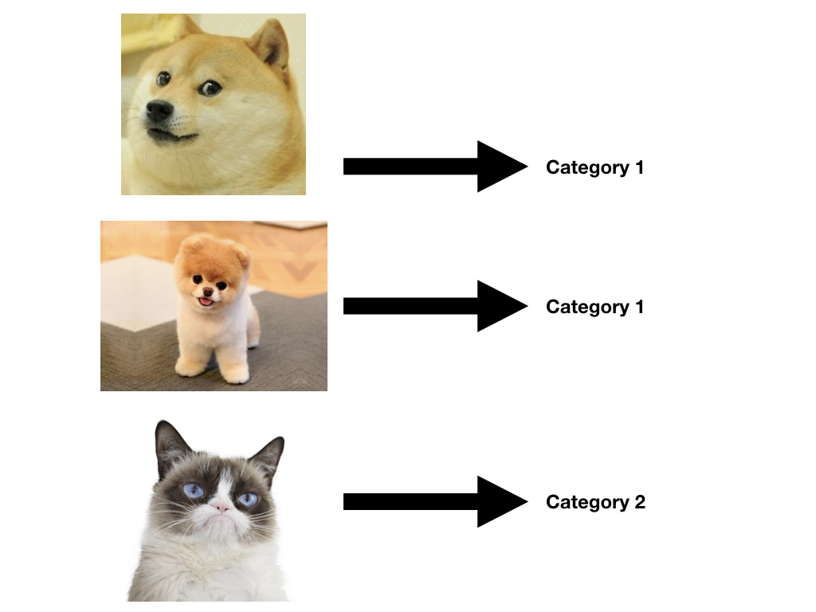

### Training a Neural Network

- Data is split into two sets: training set, and test set
- Training stage determines optimal weights for the supplied data
- Testing stage evaluates model using predictive performance
- Splitting data reduces over-fitting

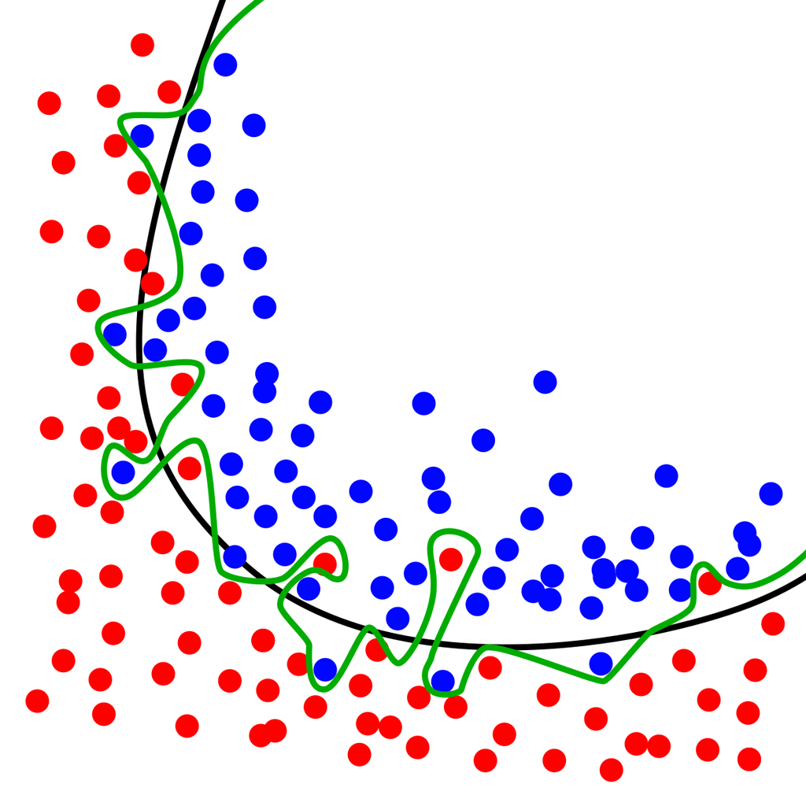

### Should you use a neural network?

Advantages:

- Neural networks work for both classification and regression
- Very good predictive performance, even with complex problems like image recognition
- Can approximate almost any function, including non-linear functions

Disadvantages:

- Prone to over-fitting
- Tuning parameters are required (number of nodes, layers)
- Provides little insight into the data (black box model)
- Can be computationally intensive

[figure not shown]

### History of Neural Networks

- 1950s: Perceptron algorithm invented
- 1960s-1970s: Single perceptrons proven to be not useful for modeling even simple nonlinear functions; research stalls
- 1980s: Multi-layer perceptron networks introduced that solve problems of single perceptrons; neural networks become populaar
- 1990s: Neural networks did not scale well, support vector machines replace them in popularity
- 2000s: Increased computational power brings back neural network popularity, deep learning introduced
- 2010s: Improvements in available data, research, and computational power make deep learning very successful and popular
- Deep Learning: A complex neural network with many hidden layers

[figure not shown]

### Data Example: Predicting Wine Type

```r
wine = read.csv('https://archive.ics.uci.edu/ml/machine-learning-databases/wine/wine.data')
names(wine) = c('label', 'alcohol', 'malic_acid', 'ash', 'alcalinity_of_ash',
                  'magnesium', 'total_phenols', 'flavanoids', 'nonflavanoid_phenols',
                  'proanthocyanins', 'color_intensity', 'hue', 'OD280_OD315_of_diluted_wines',
                  'proline')
wine$id = as.character(seq(1, nrow(wine)))
head(wine)
```

```
  label alcohol malic_acid  ash alcalinity_of_ash magnesium total_phenols
1     1   13.20       1.78 2.14              11.2       100          2.65
2     1   13.16       2.36 2.67              18.6       101          2.80
3     1   14.37       1.95 2.50              16.8       113          3.85
4     1   13.24       2.59 2.87              21.0       118          2.80
5     1   14.20       1.76 2.45              15.2       112          3.27
6     1   14.39       1.87 2.45              14.6        96          2.50
  flavanoids nonflavanoid_phenols proanthocyanins color_intensity  hue
1       2.76                 0.26            1.28            4.38 1.05
2       3.24                 0.30            2.81            5.68 1.03
3       3.49                 0.24            2.18            7.80 0.86
4       2.69                 0.39            1.82            4.32 1.04
5       3.39                 0.34            1.97            6.75 1.05
6       2.52                 0.30            1.98            5.25 1.02
  OD280_OD315_of_diluted_wines proline id
1                         3.40    1050  1
2                         3.17    1185  2
3                         3.45    1480  3
4                         2.93     735  4
5                         2.85    1450  5
6                         3.58    1290  6
```

### Preprocessing

```r
library(plyr)

# convert 'label' factor column to separate binary columns
wine.label = mutate(wine, label1 = label == '1', label2 = label == '2', label3 = label == '3', label = factor(label))
sapply(wine.label, class)
```

```
                       label                      alcohol
                    "factor"                    "numeric"
                  malic_acid                          ash
                   "numeric"                    "numeric"
           alcalinity_of_ash                    magnesium
                   "numeric"                    "integer"
               total_phenols                   flavanoids
                   "numeric"                    "numeric"
        nonflavanoid_phenols              proanthocyanins
                   "numeric"                    "numeric"
             color_intensity                          hue
                   "numeric"                    "numeric"
OD280_OD315_of_diluted_wines                      proline
                   "numeric"                    "integer"
                          id                       label1
                 "character"                    "logical"
                      label2                       label3
                   "logical"                    "logical"
```

```r
# extract just the feature names for future reference
feature.names = colnames(wine)[!(colnames(wine) %in% c('id', 'label', 'label1', 'label2', 'label3'))]
```

### Normalization

```r
# find the numeric columns
numeric = sapply(wine.label, is.numeric)
# scale/normalize only the numeric columns
wine.scaled = wine.label
wine.scaled[ ,numeric]= sapply(wine.label[,numeric], scale)
head(wine.scaled)
```

```
  label   alcohol  malic_acid        ash alcalinity_of_ash   magnesium
1     1 0.2551008 -0.50020530 -0.8221529        -2.4930372  0.02909756
2     1 0.2056453  0.01796903  1.1045562        -0.2748590  0.09964918
3     1 1.7016732 -0.34832662  0.4865552        -0.8144158  0.94626865
4     1 0.3045563  0.22345196  1.8316163         0.4445501  1.29902677
5     1 1.4914875 -0.51807338  0.3047901        -1.2940219  0.87571703
6     1 1.7264010 -0.41979894  0.3047901        -1.4738742 -0.25310893
  total_phenols flavanoids nonflavanoid_phenols proanthocyanins
1     0.5710456  0.7375437           -0.8208101      -0.5370519
2     0.8104843  1.2181890           -0.4999191       2.1399040
3     2.4865554  1.4685250           -0.9812556       1.0376281
4     0.8104843  0.6674496            0.2220856       0.4077561
5     1.5607256  1.3683906           -0.1790282       0.6702028
6     0.3316069  0.4972211           -0.4999191       0.6876992
  color_intensity        hue OD280_OD315_of_diluted_wines     proline id
1     -0.29030665  0.4059482                    1.1284966  0.96830550  1
2      0.26896630  0.3186634                    0.8023031  1.39703475  2
3      1.18101141 -0.4232572                    1.1994082  2.33388755  3
4     -0.31611925  0.3623058                    0.4619272 -0.03206274  4
5      0.72929095  0.4059482                    0.3484686  2.23861439  5
6      0.08397601  0.2750210                    1.3837785  1.73049083  6
  label1 label2 label3
1   TRUE  FALSE  FALSE
2   TRUE  FALSE  FALSE
3   TRUE  FALSE  FALSE
4   TRUE  FALSE  FALSE
5   TRUE  FALSE  FALSE
6   TRUE  FALSE  FALSE
```

### Training and Testing

```r
# split into training and testing
train.sample = sample(wine$id, 100)
test.sample = wine$id[!(wine$id %in% train.sample)]
wine.train = wine.scaled[train.sample, ]
wine.test = wine.scaled[test.sample, ]
```

### Fitting a Neural Network Using nnet

```r
library(nnet)
nnet.formula = as.formula(paste('label ~', paste(feature.names, collapse = ' + ')))
print(nnet.formula)
```

```
label ~ alcohol + malic_acid + ash + alcalinity_of_ash + magnesium +
    total_phenols + flavanoids + nonflavanoid_phenols + proanthocyanins +
    color_intensity + hue + OD280_OD315_of_diluted_wines + proline
```

```r
nnet.model = nnet(nnet.formula, data = wine.train, size = 5)
head(predict(nnet.model))
```

```
               1            2            3
119 4.140737e-14 1.000000e+00 4.423473e-11
176 2.422063e-14 5.508087e-10 1.000000e+00
24  9.999970e-01 2.949112e-06 5.868736e-08
128 2.894123e-14 1.000000e+00 7.533762e-11
138 1.882001e-14 6.346578e-10 1.000000e+00
27  9.999996e-01 3.607248e-07 6.340797e-08
```

[figure not shown]

### Fitting a Neural Network Using neuralnet

```r
library(neuralnet)
neuralnet.formula = paste('label1 + label2 + label3 ~', paste(feature.names, collapse = ' + '))
print(neuralnet.formula)
```

```
[1] "label1 + label2 + label3 ~ alcohol + malic_acid + ash + alcalinity_of_ash + magnesium + total_phenols + flavanoids + nonflavanoid_phenols + proanthocyanins + color_intensity + hue + OD280_OD315_of_diluted_wines + proline"
```

```r
neuralnet.model = neuralnet(neuralnet.formula, data = wine.train, hidden = c(5), linear.output = FALSE)
print(head(neuralnet.model$net.result[[1]]))
```

```
              [,1]           [,2]           [,3]
119 0.003137577556 0.994160590090 0.002187351500
176 0.031111803951 0.001653313555 0.979778077197
24  0.974129210813 0.008094055509 0.004854660507
128 0.003006166650 0.994225332726 0.002264175451
138 0.004600143046 0.020729499195 0.977918246328
27  0.986018692884 0.001453877676 0.015434585836
```

### Network Visualization

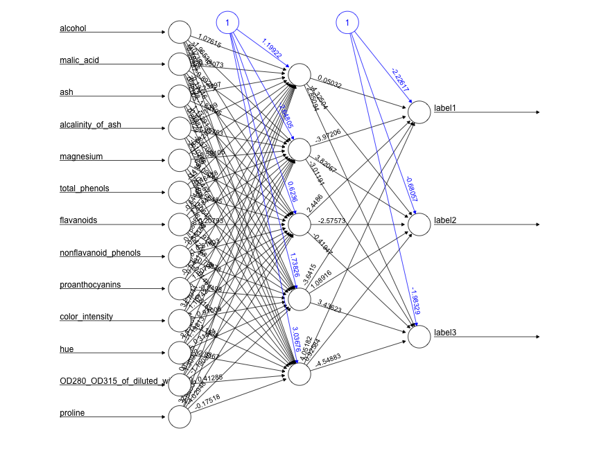

### Model Evaluation

```r
# calculate accuracy on training set
features = which(colnames(wine.label) %in% feature.names)
output = which(colnames(wine.label) %in% c('label1', 'label2', 'label3'))
train.probabilities = compute(neuralnet.model, wine.train[,features])$net.result
train.predictions = max.col(train.probabilities)
train.true.values = max.col(wine.train[,output])
print(paste('Train Accuracy:', round(100*mean(train.predictions == train.true.values)), '%'))
```

```
[1] "Train Accuracy: 100 %"
```

```r
# calculate accuracy on test set
test.predictions = max.col(compute(neuralnet.model, wine.test[,features])$net.result)
test.true.values = max.col(wine.test[,output])
print(paste('Test Accuracy:', round(100*mean(test.predictions == test.true.values)), '%'))
```

```
[1] "Test Accuracy: 99 %"
```

[figure not shown]

### Cross Validation

- Cross validation can be used to pick the optimal number of hidden nodes
- Possible rule of thumb: between 1 and the number of input variables (other rules of thumb also exist)
- k-fold cross validation: split data into k folds. For each fold, train on k-1 folds, test on the kth fold
- Choose hidden layer with best average predictive performance across folds (such as Mean Squared Error)
- Other types of cross validation: leave-one-out, Monte Carlo cross validation
- Most easily done with caret package

[figure not shown]

### Cross Validation

```r
cv = function(data, hidden, n.folds = 2, formula, features, output)
{
  # split data into 'folds' for cross validation
  fold.size = floor(nrow(data)/n.folds)
  category = NULL
  for(k in 1:n.folds){
    category = c(category, rep(k, fold.size))
  }
  # we often have rounding errors (i.e. if we have 10 folds and
  # the number of rows is not divisible by 10)
  # so randomly assign the leftover rows to different folds
  if(length(category) != nrow(data))
  {
    extra.length = nrow(data) - length(category)
    extra = sample(seq(1, n.folds), extra.length)
    category = c(category, extra)
  }
  data$cv.fold = sample(category)
```

### Cross Validation

```r
  mse = rep(NA, n.folds)
  for(k in 1:n.folds)
  {
    # extra training/test data for this fold
    train.cv = data[data$cv.fold != k,]
    test.cv = data[data$cv.fold == k,]

    # the algorithm starts out with a random set of weights
    # occasionally it starts with suboptimal weights and does not converge
    # within the allowed time (maximum steps). Rather than increasing
    # the max number of steps, which would slow down the script,
    # I retry the model until it converges
    attempts = 0
    model.cv = NULL
    while( is.null(model.cv) & attempts <= 10)
    {
      model.cv = try(neuralnet(formula, train.cv, hidden = hidden, linear.output = FALSE))
      attempts = attempts + 1
    }
    # calculate Mean Squared Error
    test.predictions = max.col(compute(model.cv, test.cv[,features])$net.result)
    test.true.values = max.col(test.cv[,output])
    mse[k] = sum((test.predictions - test.true.values)^2)/nrow(test.cv)
  }
  return(mean(mse))
}
```

### Cross Validation

```r
test.size = function(data, n.folds, formula, features, output)
{
  hidden.values = seq(1, length(features))
  n.values = length(hidden.values)
  mse.all = rep(NA, n.values)
  for(i in 1:n.values)
  {
    mse.all[i] = cv(data, hidden.values[i], n.folds, formula, features, output)
  }
  best = which.min(mse.all)
  return(hidden.values[best])
}

hidden.nodes = test.size(wine.label, n.folds = 4, neuralnet.formula, features, output)
model = neuralnet(neuralnet.formula, data = wine.train, hidden = hidden.nodes, linear.output = FALSE)
summary(model)
```

[output not shown]

[figure not shown]

Part II: Using Debugging and Profiling Tools

### R Debug

- Built-in tools in Rstudio to help you debug your code
- Enter debug mode at a certain line, on error, or when a particular function executes
- s: step into function, n: execute next statement
- f: finish function/loop, c: continue running
- Q: quit
- recover(): steps out to allow you to enter a different function
- Note: in base R, same functionality by using functions like browser(), trace(), recover()

[figure not shown]

[figure not shown]

### Debug on Error

- Tools > Global Options > uncheck “Use debug error handler only when my code contains errors”
- Debug > On Error > Break in Code
- Optional: turn warnings into errors

```r
options(warn = 2)
```

### Debug Example

```r
foo = function(x){
  if(x > 0)
  {
    salutation = "Hello"
  } else
  {
    salutation = "Goodbye"
  }
  print(salutation)
}
foo(x = log(-1))
```

### Debug Tool

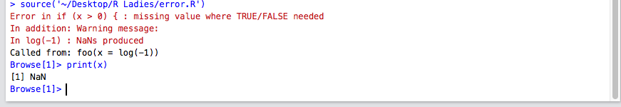

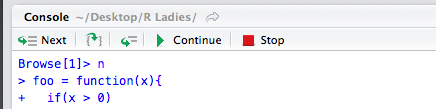

### Traceback

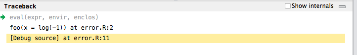

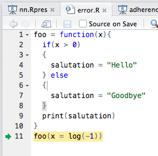

[figure not shown]

### R Profiler

- Built-in tools in Rstudio to help you identify slow parts of your code
- Note: in base R, same functionality by using functions like Rprof(), profr library

### Comparing Scripts

[figure not shown]

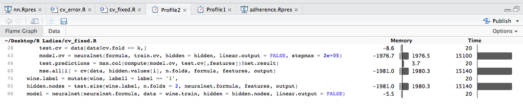

### References

- [Classification with Neural Networks](https://www.r-bloggers.com/multilabel-classification-with-neuralnet-package/)
- [Customizing R Presentations](https://rstudio-pubs-static.s3.amazonaws.com/27777_55697c3a476640caa0ad2099fe914ae5.html)
- [Dummies' Introduction to Neural Networks](https://medium.com/technologymadeeasy/for-dummies-the-introduction-to-neural-networks-we-all-need-c50f6012d5eb)
- [Cross Validation for selecting hidden node number](https://firsttimeprogrammer.blogspot.com.au/2015/09/selecting-number-of-neurons-in-hidden.html)
- [Deep Learning 101](https://beamandrew.github.io/deeplearning/2017/02/23/deep_learning_101_part1.html)
- [Debugging with Rstudio](https://support.rstudio.com/hc/en-us/articles/205612627-Debugging-with-RStudio)

Questions?

[figure not shown]